# Assessing the available evidence with Bayesian meta-analyses

Audrey Bürki

In cognitive psychology/experimental psychology, we often rely on experimental data to test our theories. It is often the case that different studies perform the same experiments. Meta-analyses can be used to provide a summary of the empirical evidence available at a given point in time for any given effect.

Meta-analyses are incredibly useful because they quantify the evidence on which we can build our next studies and theories. They provide an idea of the size of an effect (how bit ig is) and of its precision. This can be used to run power analyses (analyses that help decide how many participants are needed to find an effect in a future experiment) and build more precise computational models.

In the last few years (starting during the pandemic, when it was difficult at first to collect new experimental data) we conducted Bayesian meta-analyses of several experimental effects in language production research. In addition, having access to original datasets, we were able to test novel hypotheses about these effects. Here are a few examples:

## Syllable frequency effect (or why are we faster at saying bri than blo?)

Words made of frequent syllables can be prepared faster for production than words made of low frequency syllables. This effect has been used to constrain models of word production and in particular, to argue that syllables are stored in the long-term memory of the speaker. The figure below shows the results of a meta-analysis of this effect. This is a posterior distribution: it shows the most likely value of this effect (difference, in milliseconds between words with low and words with high syllable frequencies) as well as other possible values and their probabilities.

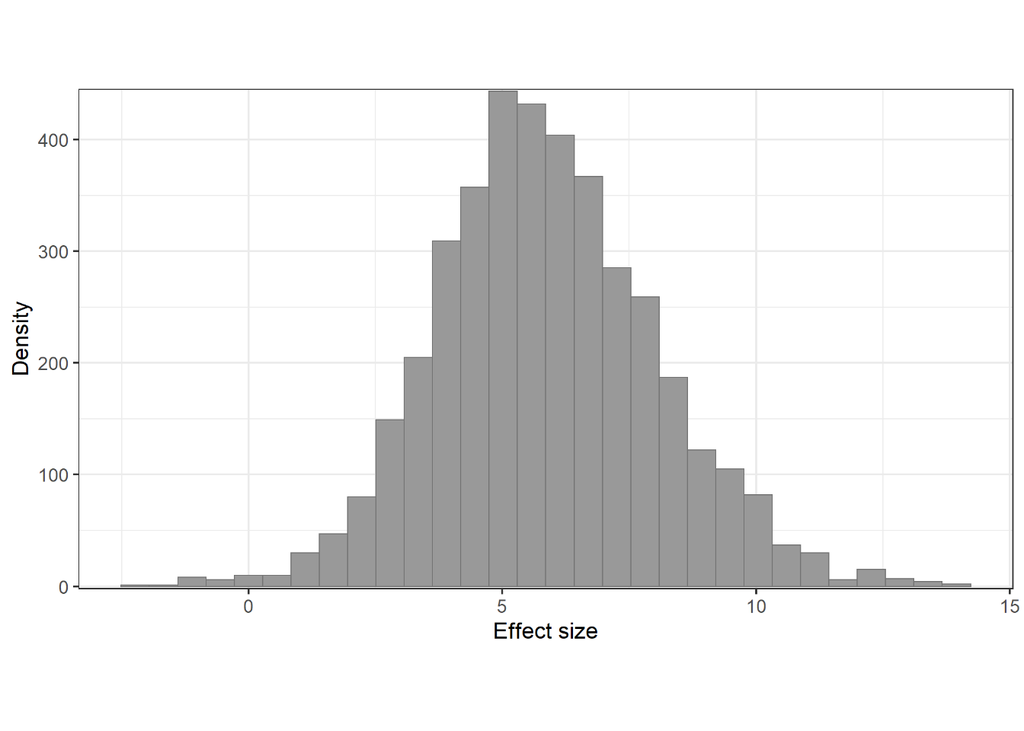

### Take home message

Most values are positive, the meta-analysis suggests that the effect is “real” but:

- Failed attempts to detect the effect are not published and therefore not included.
- The effect is very small, and as a consequence, very large sample sizes will be required to detect this effect

The code and data to reproduce this analysis can be accessed [here](https://osf.io/4nmbj/)

## Effects of distractors (or why are we faster at saying “Spider” with the word “Boat” written on top than with the word “Ant”?)

The picture-word paradigm is a variant of the Stroop paradigm. Participants name a picture and have to ignore a written word presented together with the picture, as in the picture below.

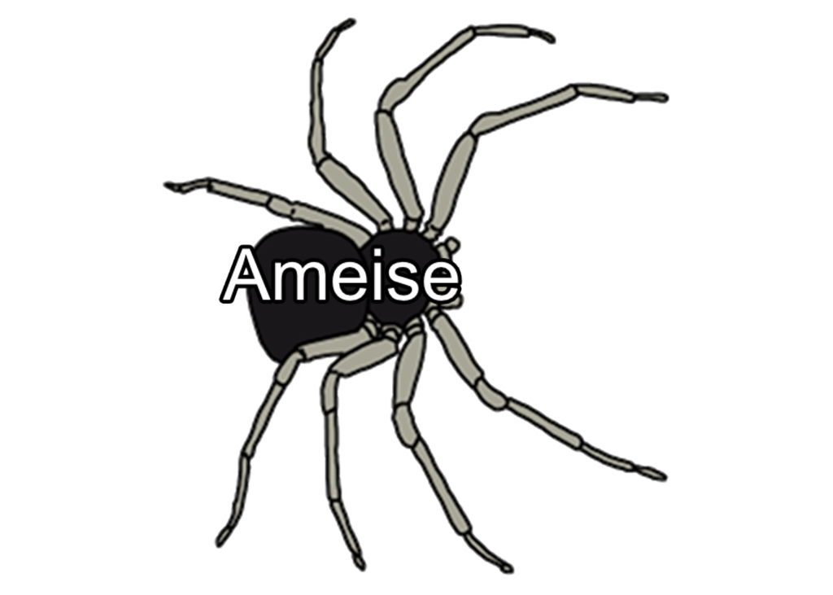

The relationship between the word associated with the picture and the distractor impacts how quickly the picture can be named. We conducted Bayesian analyses of several experimental effects: semantic interference, distractor frequency, gender congruency… Overall, what we see is the following:

- Main effects, who were already discovered in the 80s or in the 90s are reliable.
- Evidence on moderators of these effects, which is crucial to disentangle existing theories of these effects (and further define models of word production), is often lacking.

### References, with links to data and code

Bürki, A. van den Hoven, E., Schiller, N.O., & Dimitrov, N. (submitted). Cross-linguistic differences in gender congruency effects: Evidence from meta-analyses. [pre-print](https://arxiv.org/abs/2109.03490)

Bürki, A., Alario, X., & Vasishth, S. (2022). When words collide: Bayesian meta-analyses of distractor and target properties in the picture-word interference paradigm. **The Quarterly Journal of Experimental Psychology**. ([data & scripts](https://osf.io/sjn5b/)) ([pre-print](https://arxiv.org/abs/2008.03972))

Fuhrmeister, P., & Bürki, A. (2022). Distributional properties of semantic interference in picture naming: Bayesian meta-analyses. **Psychonomic Bulletin & Review**, 29(2):635-647. doi: 10.3758/s13423-021-02016-6. ([data & scripts](https://osf.io/v2fx5/)) ([paper](https://link.springer.com/article/10.3758/s13423-021-02016-6))

Bürki, A., Elbuy, S., Madec, S., & Vasishth, S. (2020). What did we learn from forty years of research on semantic interference? A Bayesian meta-analysis. **Journal of Memory and Language.** ([paper](https://www.sciencedirect.com/science/article/pii/S0749596X20300395)) ([data & scripts](https://osf.io/k6f4c/)) doi:10.1016/j.jml.2020.104125